# Short demo

Sangwon Hyun, Mattias Rolfe Cape, Francois Ribalet, Jacob Bien

# Artificial data

First, generate data:

```r
set.seed(0)
datobj = generate_data_generic(p=5, TT=300, fac=.5, nt=2000, dimdat = 3)
ylist = datobj$ylist
X = datobj$X
```

This produces three dimensional cytograms `ylist` and covariates `X`.

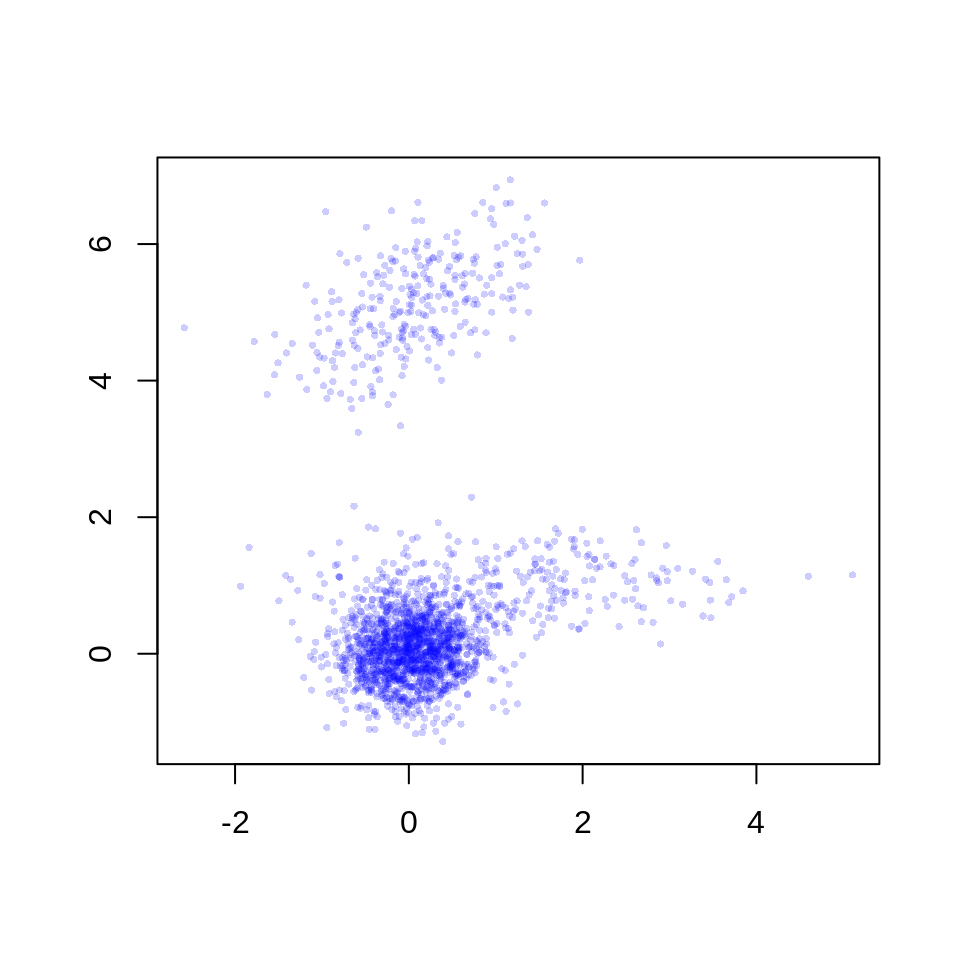

```r
plot(ylist[[1]][,1:2], ylab="", xlab="", pch=16, col=rgb(0,0,1,0.2), cex=.5)
```

Especially if your data is a time series, it could be useful to plot the covariates once across time.

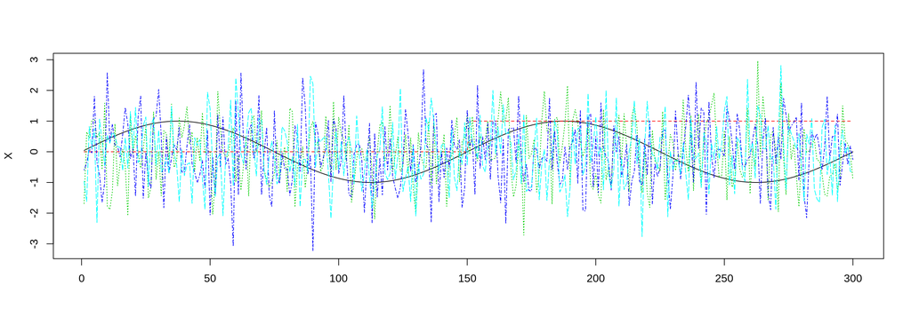

```r
matplot(X, type='l')
```

Internally, `flowmix()` repeats the estimation 5 (the default) times, and returns the estimated model providing the best data fit.

```r
numclust = 4
set.seed(0)
res = flowmix(ylist = ylist, X = X, numclust = numclust,
              niter = 300, mean_lambda = 0.01, prob_lambda = 0.001,
              nrep = 1)
print(res)
```

```
## [1] "0 out of 60 regression coefficients for the cluster centers, are zero."
## [1] "18 out of 20 regression coefficients for the cluster probabilities, are zero."
## [1] "The algorithm converged in 16 EM iterations."
```

The cluster probabilities look like this:

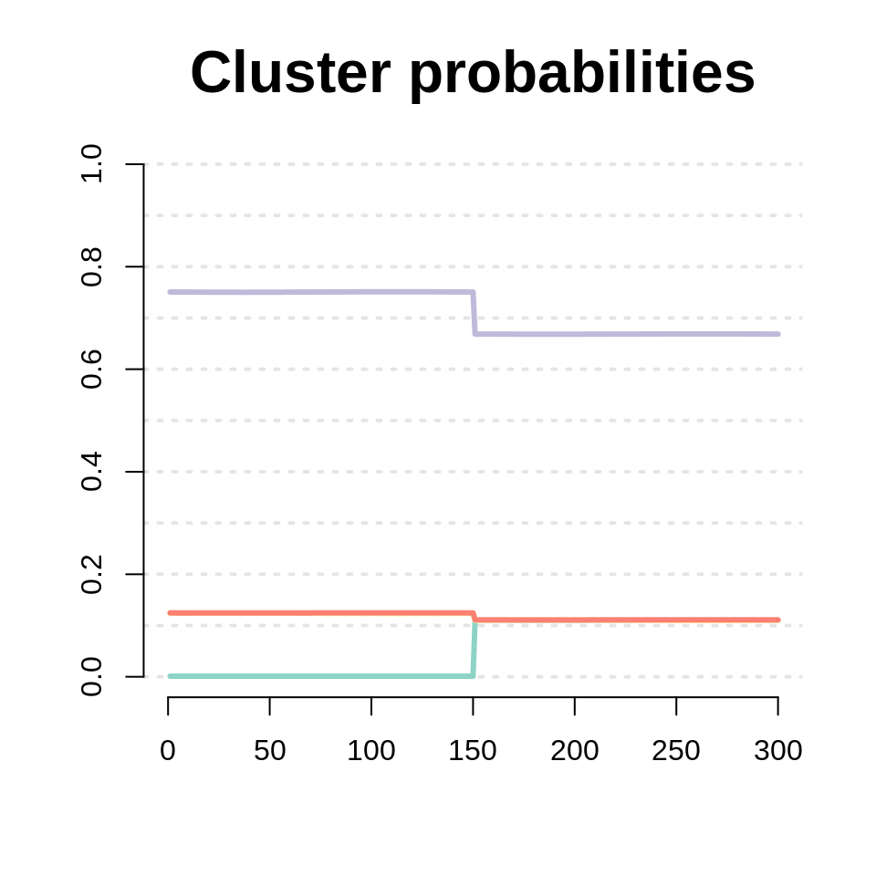

```r
plot_prob(res)
```

The estimated cluster means along the three dimensions look like this:

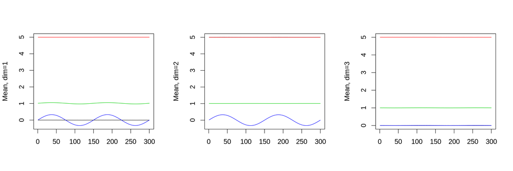

```r
par(mfrow = c(1,3), cex=1.2)
for(idim in 1:3){
  matplot(res$mn[,idim,], type='l', lty=1, ylab = paste0("Mean, dim=", idim))
}
```

The estimated cluster means, drawn on scatterplots of the data two dimensions at a time, look like this:

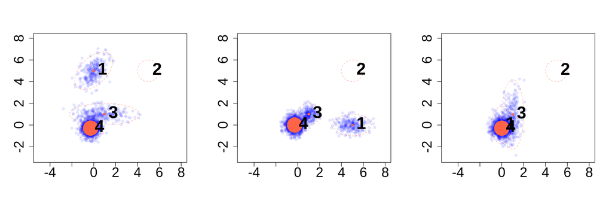

```r
par(mfrow = c(1,3))
ylim = c(-3,8)
xlim = c(-5,8)
for(dims in list(c(1,2), c(2,3), c(3,1))){
  scatterplot_2d(ylist, res, 100, dims = dims, cex_fac=1, ylim=ylim, xlim=xlim)
}
```

Next, the first two dimensions only, shown at three different time points:

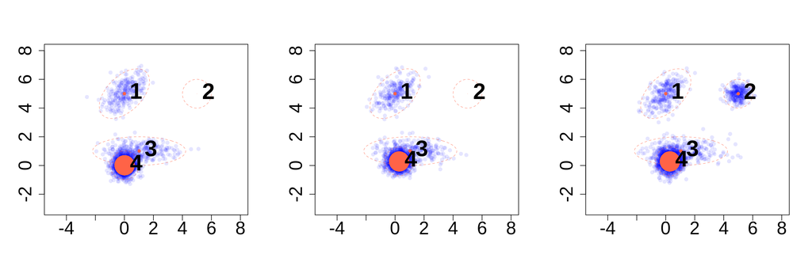

```r
par(mfrow = c(1,3))
for(tt in c(1,50,200)){
  scatterplot_2d(ylist, res, tt,   dims = c(1,2), cex_fac=1, ylim=ylim, xlim=xlim)
}
```

# Cross-validation

Of course, the regularization parameters should be chosen from the data, in our case using cross-validation. This is done using this code:

```r
## Define the locations to save the CV.
destin = "."

## Define the CV folds (e.g. 5 big consecutive time blocks)
folds = blockcv_make_folds(ylist = ylist, nfold = 5)

## Define the candidate lambda values (logarithmically spaced)
cv_gridsize = 5
prob_lambdas =  logspace(min = 0.0001, max = 1, length = cv_gridsize)
mean_lambdas = logspace(min = 0.0001, max = 1, length = cv_gridsize)

## Example of one CV job for one pair of regularization parameters (and CV folds
## and EM replicates)
ialpha = 1
ibeta = 1
ifold = 1
irep = 1
one_job(ialpha = ialpha,
        ibeta = ibeta,
        ifold = ifold,
        irep = irep,
        folds = folds,
        destin = destin,
        mean_lambda = mean_lambdas, prob_lambdas = prob_lambdas,
        ## The rest that is needed explicitly for flowmix()
        ylist = ylist,
        countslist = NULL,
        X = X,
        numclust = 4,
        maxdev = 0.5)
```

Since this is clearly parallelizable, we recommend using multiple computers or servers.

Also, since it is not clear what to use for the maximum value for the candidate regularization parameters, one can numerically obtain this like this:

```r
maxres = get_max_lambda(destin, "maxres.Rdata",
                        ylist = ylist,
                        countslist = NULL,
                        X = X,
                        numclust = 4,
                        maxdev = 0.5,
                        max_lambda_alpha = 40,
                        max_lambda_beta =  2)
```

(Next up is to wrap most of the above into a single function, like this:)

```r
cvres = cv.flowmix(ylist = ylist, X = X, numclust = numclust,
                   max_mean_lambda = 1,
                   max_prob_lambda = 1,
                   cv_gridsize = 10)
```

# Binning data

If the data contains too many particles, there is an option to reduce the size of `ylist` and deal with counts. The new object `countslist` can be *additionally* provided to `flowmix()`. Here is an example:

```r
## bin this data
grid = make_grid(ylist, gridsize = 30, grid.ind=FALSE)
obj = bin_many_cytograms(ylist,grid, mc.cores = 8, verbose=FALSE)
ylist = obj$ybin_list
countslist = obj$counts_list

## Run the algorithm on binned data
res = flowmix(ylist, X, numclust = numclust,
                   countslist = countslist,
                   mean_lambda = 0.01,
                   prob_lambda = 0.01,
                   verbose = FALSE,
                   maxdev = 0.5)
```

# Real data

You can repeat the above code blocks, with real data.

```r
## Load data
load(file = "~/repos/flowmix/demo-MGL1704.Rdata")
X = X %>% select(-time, -lat, -lon) %>% as.matrix()
ylist = ybin_list
countslist = biomass_list

## Estimate model
set.seed(0)
res = flowmix(ylist, X, numclust = 10,
              countslist = countslist,
              mean_lambda = 0.01,
              prob_lambda = 0.1,
              maxdev = 0.5,
              nrep = 1)
```

Now visualizing the results as before.

```r
## Default print
print(res)
```

```
## [1] "4 out of 1110 regression coefficients for the cluster centers, are zero."
## [1] "369 out of 370 regression coefficients for the cluster probabilities, are zero."
## [1] "The algorithm converged in 52 EM iterations."
```

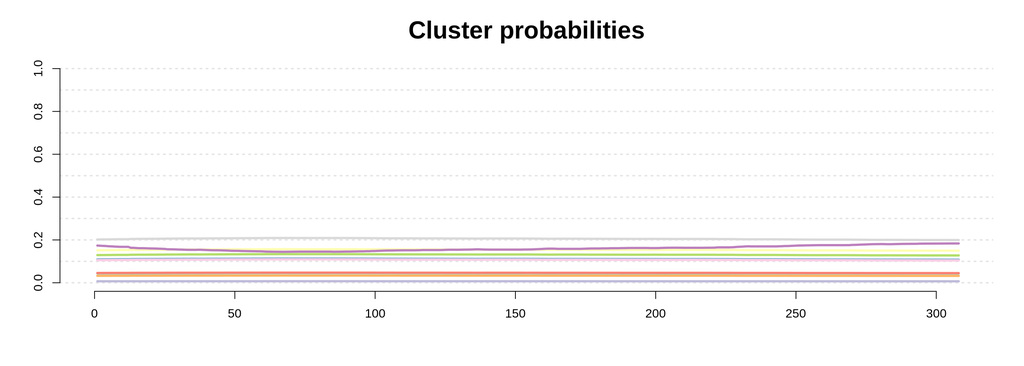

```r
## Plot estimated probabilities
plot_prob(res)
```

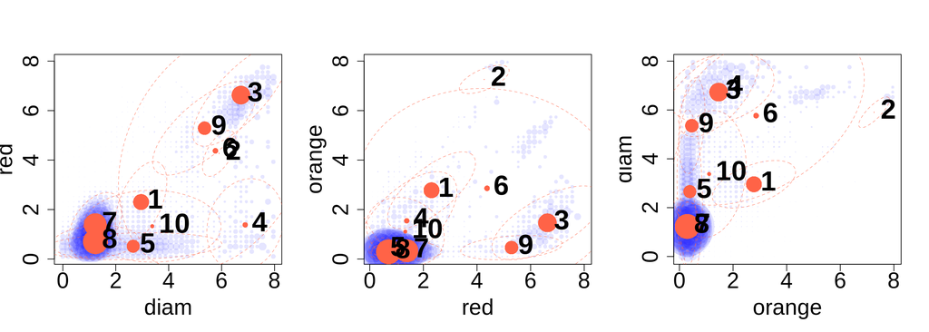

```r
## Three scatterplots of one time point
par(mfrow = c(1,3))
ylim = c(-3,8)
xlim = c(-5,8)
dimnames = c("diam", "red", "orange")
for(dims in list(c(1,2), c(2,3), c(3,1))){
  scatterplot_2d(ylist = ylist,
                 countslist = countslist,
                 obj = res,
                 300,
                 dims = dims, cex_fac=8,
                 pt_col = rgb(0 ,0, 1, 0.1),
                 xlab = dimnames[dims[1]],
                 ylab = dimnames[dims[2]])
}
```